# Predict POC values from plankton

Train a XGBoost model to predict POC values from a set of PCA-selected variables of plankton diversity.

Author

Thelma Panaïotis

## Set-up and load data

```r
source("utils.R")
load("data/04.all_data.Rdata")
output_filename <- "data/08.all_preds_poc_from_plankton_pca.Rdata"
```

## Data inspection

### Response variable

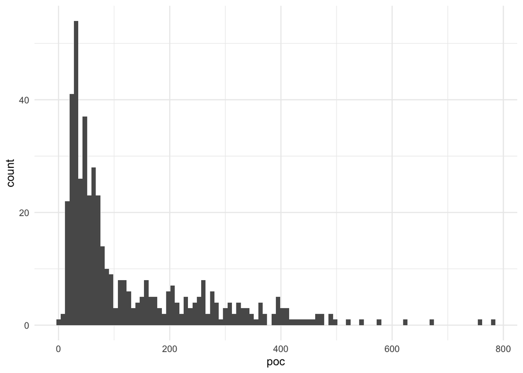

```r
df %>% ggplot() + geom_histogram(aes(x = poc), bins = 100)
```

The distribution is not normal, this is problematic. Let’s try a log-transformation.

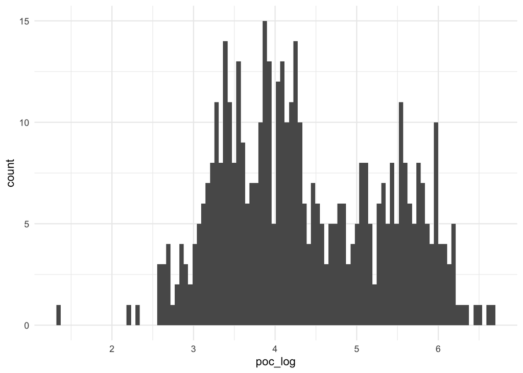

```r
df <- df %>% mutate(poc_log = log(poc))
df %>% ggplot() + geom_histogram(aes(x = poc_log), bins = 100)
```

This is much better. We’ll then try to predict `log(poc)`.

### Explanatory variables

Select explanatory variables.

```r
# Explanatory variables
exp_vars <- df %>% select(ta_ric:mo_spe) %>% colnames()
# Metadata variables
meta_vars <- df %>% select(lon, lat, datetime) %>% colnames()
```

Let’s run a quick PCA. This allows us to have at correlations within our datasets as well as the main axes of variance.

```r
# Need to remove lon and lat and to scale because units differ between variables
df_pca <- df %>% select(poc, poc_log, all_of(exp_vars))
pca_all <- FactoMineR::PCA(df_pca, quanti.sup = 1:2, scale.unit = TRUE, graph = FALSE)
```

Plot eigenvalues.

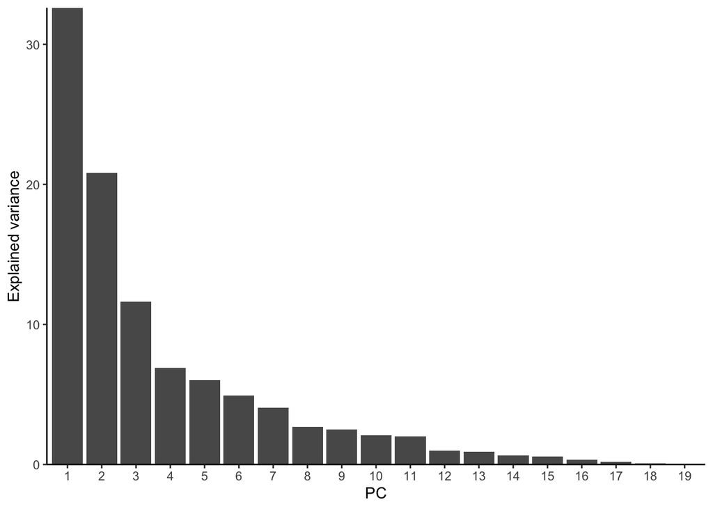

```r
eig <- pca_all$eig %>%
  as.data.frame() %>%
  rownames_to_column(var = "comp") %>%
  as_tibble() %>%
  mutate(
    comp = str_remove(comp, "comp "),
    comp = as.numeric(comp),
    comp = as.factor(comp)
  ) %>%
  rename(var = `percentage of variance`, cum_var = `cumulative percentage of variance`)

eig %>%
  ggplot() +
  geom_col(aes(x = comp, y = var)) +
  theme_classic() +
  scale_y_continuous(expand = c(0, 0)) +
  labs(x = "PC", y = "Explained variance")
```

Let’s keep first 3 PCs to predict POC values.

Plot first plane.

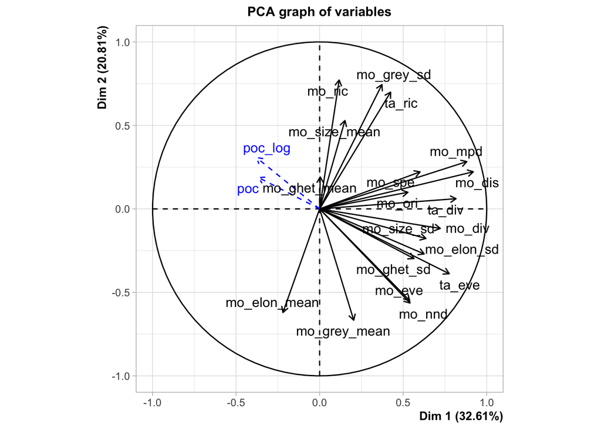

```r
plot(pca_all, choix="var", axes = c(1, 2))
```

Extract coordinates in the PCA space.

```r
## Get coordinates of individuals
inds <- pca_all$ind$coord %>% as_tibble()
# Set nice names for columns
colnames(inds) <- str_c("dim", paste(c(1:ncol(inds))))
# And join with initial dataframe of objects
inds <- df %>%
  bind_cols(inds)
```

Plot maps of profiles.

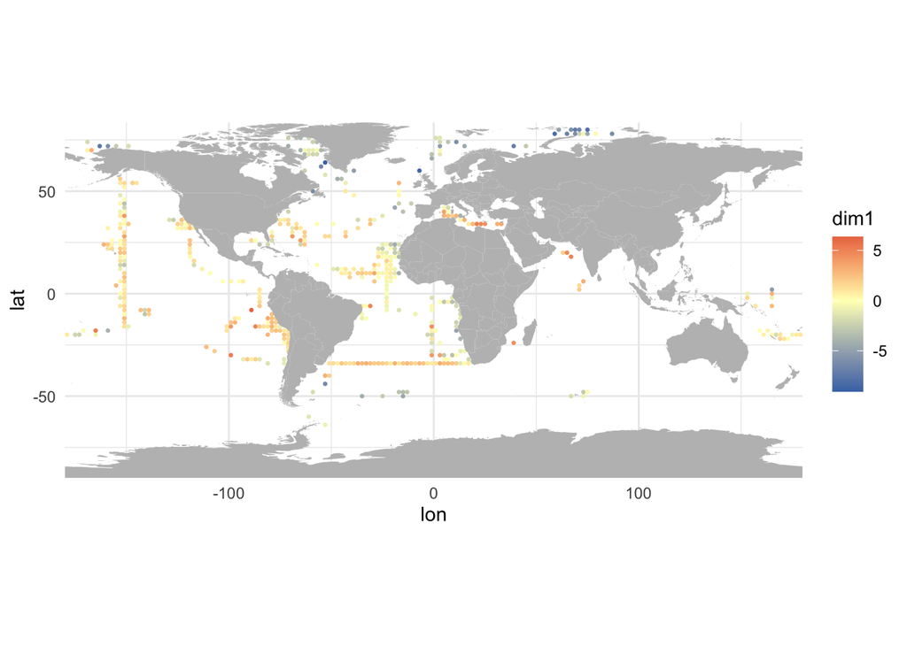

```r
ggmap(inds, "dim1", type = "point", palette = div_pal)
```

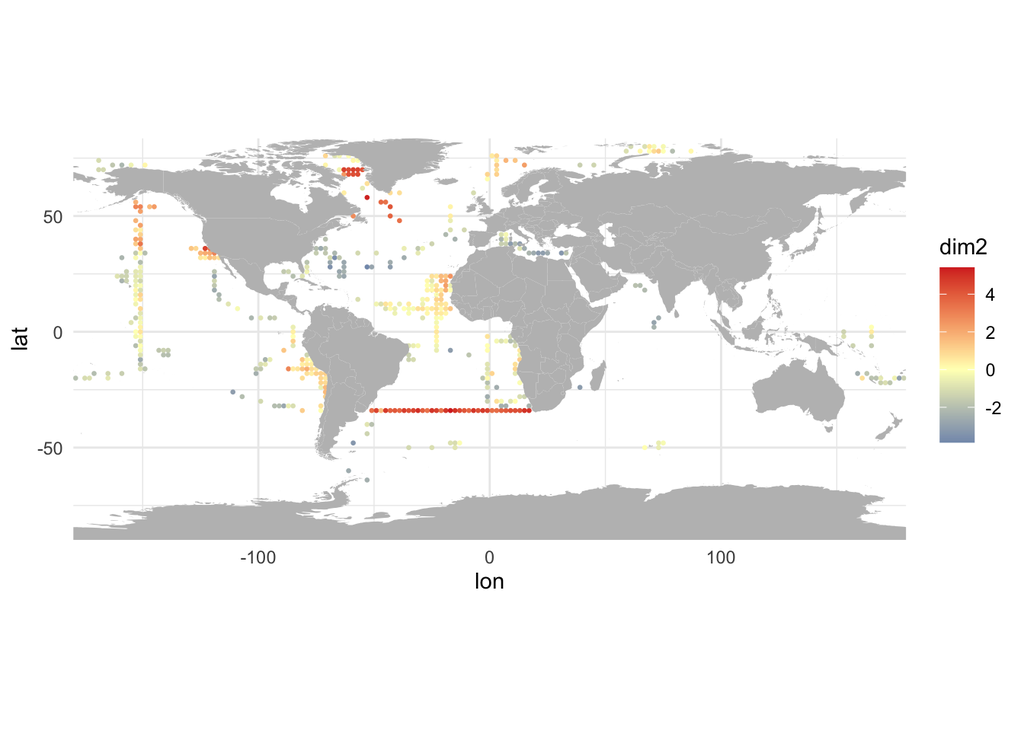

```r
ggmap(inds, "dim2", type = "point", palette = div_pal)
```

## Data split

```r
# Replace original data by data with PC projections
df <- inds

# Define new set of exp variables
exp_vars <- df %>% select(dim1, dim2, dim3) %>% colnames()
```

Let’s take 80% of the data to fit the model, and keep 20% to test the model at the very end. We stratify our split by `poc_log`, the response value, so that both training and testing sets are representative of the whole range of values.

```r
# Train VS test, stratified
df_split <- initial_split(df, prop = 0.8, strata = poc_log)
df_train <- training(df_split)
df_test <- testing(df_split)
```

To evaluate model performance during training, we’ll use cross-validation on the training set, with 10 folds, again stratified by `poc_log`.

```r
# Cross-validation, 10 folds, stratified
df_folds <- vfold_cv(df_train, v = 10, strata = poc_log)
```

## Model definition

Let’s define a XGBoost regression model, with tunable hyperparameters:

- `trees`: number of trees
- `tree_depth`: maximum depth (i.e. number of splits) in a tree
- `min_n`: minimum number of objects in a node to split further
- `learn_rate`

```r
# Define a xgboost model with hyperparameters to tune
xgb_spec <- boost_tree(
  trees = tune(),
  tree_depth = tune(),
  min_n = tune(),
  #loss_reduction = tune(),
  #sample_size = tune(),
  #mtry = tune(),
  learn_rate = tune()
) %>%
  set_mode("regression") %>%
  set_engine("xgboost", num.threads = n_cores)
extract_parameter_set_dials(xgb_spec)
```

```
Collection of 4 parameters for tuning

 identifier       type    object
      trees      trees nparam[+]
      min_n      min_n nparam[+]
 tree_depth tree_depth nparam[+]
 learn_rate learn_rate nparam[+]
```

The model will be run on 14 cores in parallel.

## Recipe

Let’s use a recipe to define the model formula and assign roles to variables. We want to predict `poc_log` from all other variables expect `lon`, `lat` and original `poc` values, yet it is convenient to keep these in the dataset.

```r
# Generate formula from list of explanatory variables
# NB: we also add metadata variables and untransformed "poc" for technical reasons but these will not be used to fit the model
xgb_form <- as.formula(paste("poc_log ~ ", paste(c("poc", meta_vars, exp_vars), collapse = " + "), sep = ""))

xgb_rec <- recipe(xgb_form, data = df_train) %>%
  update_role(lon, lat, datetime, new_role = "coords") %>% # These variables can be retained in the data but not included in the model
  update_role(poc, new_role = "untransformed outcome")
summary(xgb_rec)
```

```
# A tibble: 8 × 4
  variable type      role                  source
  <chr>    <list>    <chr>                 <chr>
1 poc      <chr [2]> untransformed outcome original
2 lon      <chr [2]> coords                original
3 lat      <chr [2]> coords                original
4 datetime <chr [1]> coords                original
5 dim1     <chr [2]> predictor             original
6 dim2     <chr [2]> predictor             original
7 dim3     <chr [2]> predictor             original
8 poc_log  <chr [2]> outcome               original
```

## Workflow

Set-up the workflow with the recipe and the model.

```r
xgb_wflow <- workflow() %>%
  add_recipe(xgb_rec) %>%
  add_model(xgb_spec)
```

## Gridsearch

It is now time to perform the gridsearch to find the best hyperparameters for our model. We first need to define a grid with the hyperparameters we want to try. We use `grid_latin_hypercube` to generate a space-filling grid of size `30`.

```r
xgb_grid <- grid_latin_hypercube(
  trees(),
  learn_rate(),
  tree_depth(),
  min_n(),
  #loss_reduction(),
  #sample_size = sample_prop(),
  #finalize(mtry(), df_train),
  size = 30
)
xgb_grid
```

```
# A tibble: 30 × 4
   trees   learn_rate tree_depth min_n
   <int>        <dbl>      <int> <int>
 1  1466 0.0170                4    22
 2   556 0.00000494            7    12
 3  1724 0.0122               10    37
 4  1477 0.0000137            14    40
 5  1187 0.000000673          11    25
 6   249 0.0000000859          9    19
 7   377 0.000000268          11    15
 8  1357 0.00411               8     3
 9  1582 0.00000925            5    16
10   873 0.00000149            6    30
# ℹ 20 more rows
```

Tune the grid to find the best hyperparameters, in parallel. This is done on our cross-validation folds: for each fold, a model is fitted on training data and evaluated on validation data.

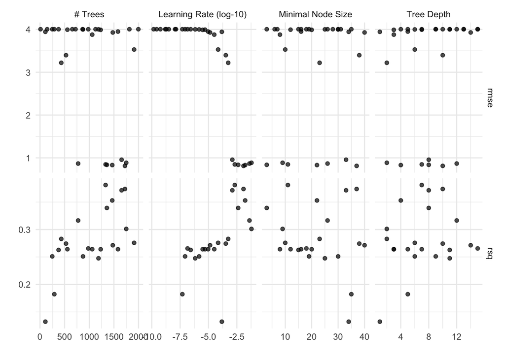

```r
doParallel::registerDoParallel()
xgb_res <- tune_grid(
  xgb_wflow,
  resamples = df_folds,
  grid = xgb_grid,
  control = control_grid(save_pred = TRUE)
)
autoplot(xgb_res)
```

Select the best set of hyperparameters based on `rmse` value.

```r
show_best(xgb_res, metric = "rmse")
```

```
# A tibble: 5 × 10
  trees min_n tree_depth learn_rate .metric .estimator  mean     n std_err
  <int> <int>      <int>      <dbl> <chr>   <chr>      <dbl> <int>   <dbl>
1  1724    37         10    0.0122  rmse    standard   0.813    10  0.0323
2  1466    22          4    0.0170  rmse    standard   0.832    10  0.0291
3  1357     3          8    0.00411 rmse    standard   0.837    10  0.0269
4  1331    11          7    0.00207 rmse    standard   0.847    10  0.0273
5   774    26         12    0.0406  rmse    standard   0.867    10  0.0320
# ℹ 1 more variable: .config <chr>
```

```r
best_xgb <- select_best(xgb_res, metric = "rmse")
```

## Finalize

Let’s now finalize our model with the selected set of hyperparameters.

```r
final_xgb <- finalize_workflow(
  xgb_wflow,
  best_xgb
)
```

Fit the model on training data.

```r
final_res <- fit(final_xgb, df_train)
```

```
[15:39:14] WARNING: src/learner.cc:767:
Parameters: { "num_threads" } are not used.
```

Predict test data, and apply `exp` transformation as we predict the `log` of `poc` values. Still, we will evaluate model performances with predictions of `poc_log` as it is closer to a normal distribution.

```r
test_preds <- augment(final_res, new_data = df_test) %>%
  mutate(split = "test", .before = lon) %>% # tag split
  rename(.pred_logged = .pred) %>% # prediction is actually log of prediction
  mutate(.pred = exp(.pred_logged)) %>% # apply exp to prediction
  mutate(residuals = .pred_logged - poc_log) # compute residuals
```

## Model evaluation

### Prediction metrics

Let’s have a look at prediction metrics on the test set.

```r
rmse(test_preds, truth = poc_log, estimate = .pred_logged)
```

```
# A tibble: 1 × 3
  .metric .estimator .estimate
  <chr>   <chr>          <dbl>
1 rmse    standard       0.817
```

```r
rsq(test_preds, truth = poc_log, estimate = .pred_logged)
```

```
# A tibble: 1 × 3
  .metric .estimator .estimate
  <chr>   <chr>          <dbl>
1 rsq     standard       0.294
```

### Prediction VS truth

Plot predictions VS truth, both in the log-transformed space and in the non log-transformed space.

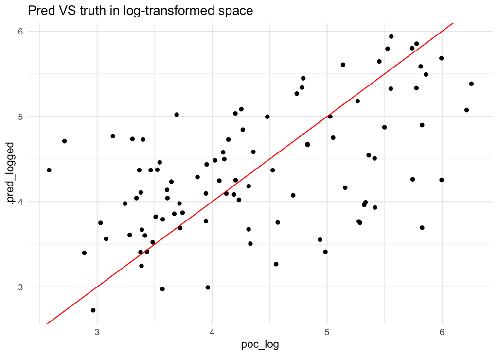

```r
test_preds %>%
  ggplot() +
  geom_point(aes(x = poc_log, y = .pred_logged)) +
  geom_abline(slope = 1, color = "red") +
  labs(title = "Pred VS truth in log-transformed space")
```

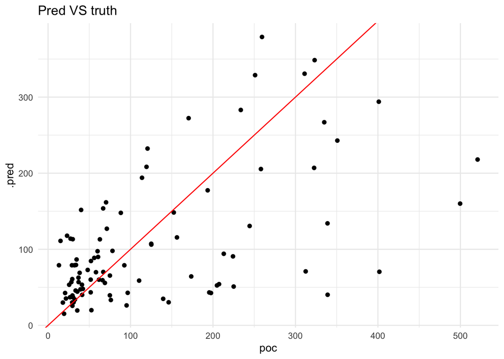

```r
test_preds %>%
  ggplot() +
  geom_point(aes(x = poc, y = .pred)) +
  geom_abline(slope = 1, color = "red") +
  labs(title = "Pred VS truth")
```

### Residuals

Finally, let’s have a look at residuals.

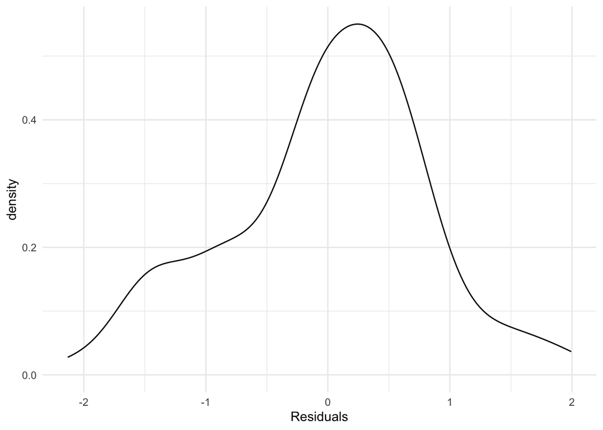

```r
ggplot(test_preds) +
  geom_density(aes(x = residuals)) +
  labs(x = "Residuals")
```

## All predictions

```r
# Predict training set
train_preds <- augment(final_res, new_data = df_train) %>%
  mutate(split = "train", .before = lon) %>% # tag split
  rename(.pred_logged = .pred) %>% # prediction is actually log of prediction
  mutate(.pred = exp(.pred_logged)) %>% # apply exp to prediction
  mutate(residuals = .pred_logged - poc_log) # compute residuals

# Join predictions for test and training sets
all_preds <- bind_rows(test_preds, train_preds)

# Save all predictions
save(all_preds, file = "data/07.all_preds_poc_from_plankton_best.Rdata")
```

## Model interpretation

Let’s feed our model to `explain_tidymodel`, but first we need to select predictors only.

```r
# Select only predictors
vip_train <- xgb_rec %>% prep() %>% bake(new_data = NULL, all_predictors())


# Explainer
xgb_explain <-
  explain_tidymodels(
    model = extract_fit_parsnip(final_res),
    data = vip_train,
    y = df_train %>%  pull(poc_log)
  )
```

```
Preparation of a new explainer is initiated
  -> model label       :  model_fit  (  default  )
  -> data              :  372  rows  3  cols
  -> data              :  tibble converted into a data.frame
  -> target variable   :  372  values
  -> predict function  :  yhat.model_fit  will be used (  default  )
  -> predicted values  :  No value for predict function target column. (  default  )
  -> model_info        :  package parsnip , ver. 1.1.1 , task regression (  default  )
  -> predicted values  :  numerical, min =  2.560149 , mean =  4.376014 , max =  6.004935
  -> residual function :  difference between y and yhat (  default  )
  -> residuals         :  numerical, min =  -1.713468 , mean =  -1.017722e-05 , max =  1.691715
  A new explainer has been created!
```

### Variable importance

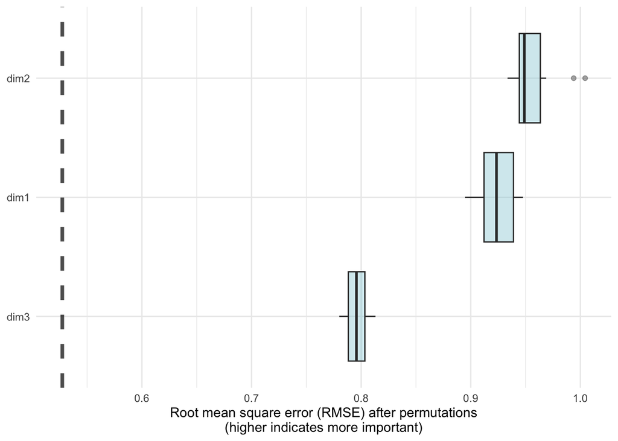

```r
xgb_var_imp <- model_parts(xgb_explain)
ggplot_imp(xgb_var_imp)
```

### Partial dependence plots

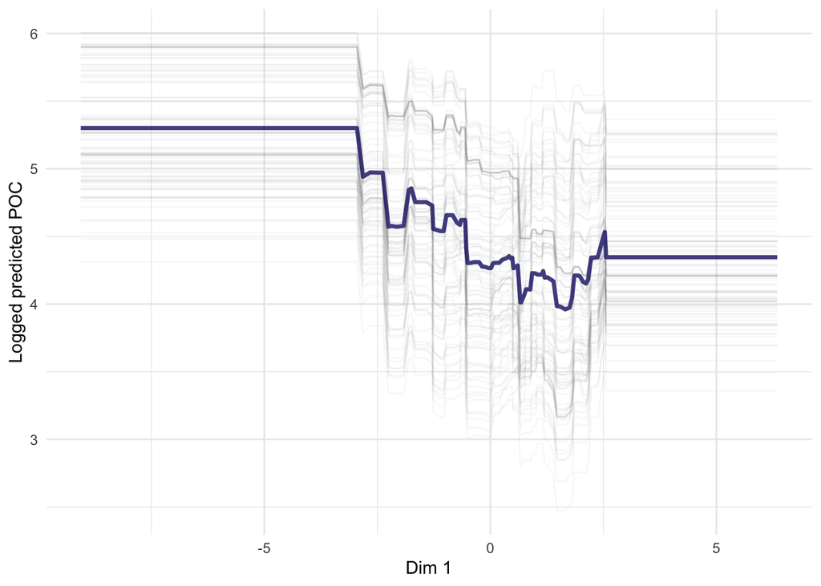

```r
xgb_pdp_dim1 <- model_profile(explainer = xgb_explain, variables = c("dim1"))
ggplot_pdp(xgb_pdp_dim1, dim1) +
  labs(x = "Dim 1", y = "Logged predicted POC")
```

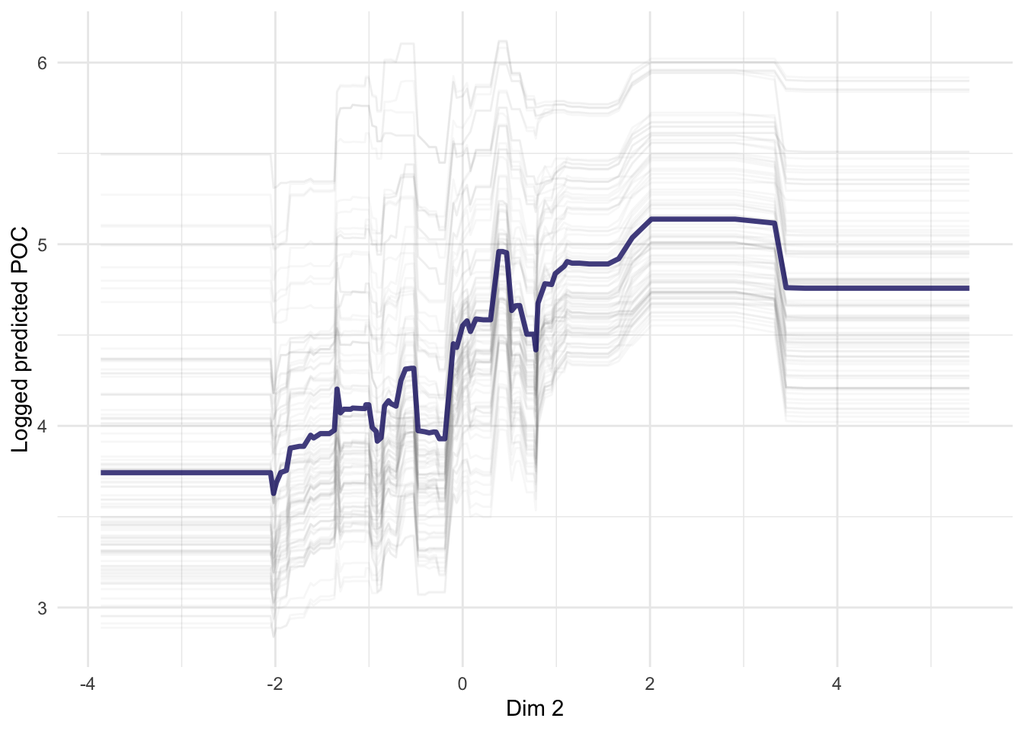

```r
xgb_pdp_dim2 <- model_profile(explainer = xgb_explain, variables = c("dim2"))
ggplot_pdp(xgb_pdp_dim2, dim2) +
  labs(x = "Dim 2", y = "Logged predicted POC")
```

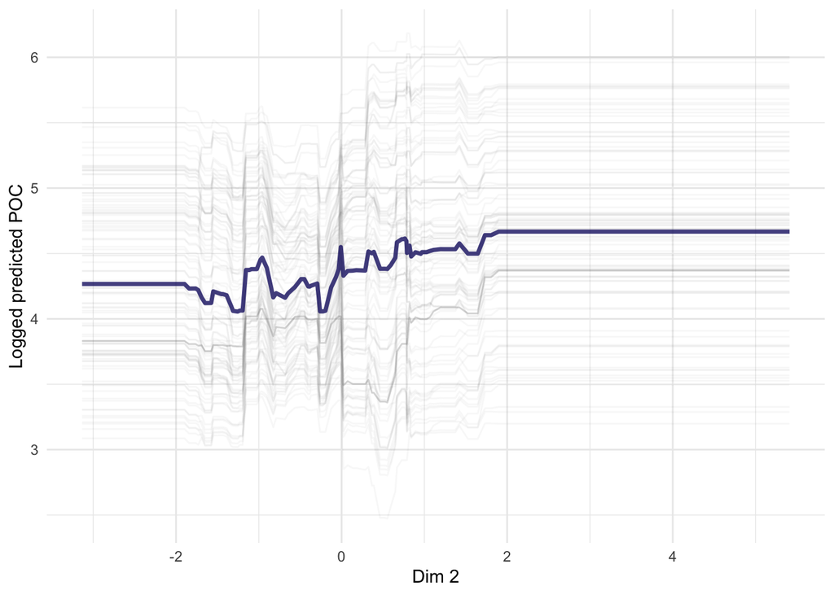

```r
xgb_pdp_dim3 <- model_profile(explainer = xgb_explain, variables = c("dim3"))
ggplot_pdp(xgb_pdp_dim3, dim3) +
  labs(x = "Dim 2", y = "Logged predicted POC")
```

## Conclusion

Using only the first 3 axes of a PCA fed with variables describing plankton diversity, we can explain 29% of POC variance.